# Resumes Answer Guideline

## The Question

Bertrand and Mullainathan (2004) sent 4,870 fictitious resumes to help-wanted ads in Boston and Chicago newspapers, randomly assigning each resume an African-American-sounding or White-sounding name. Our data records, for each resume, whether it received a callback, along with the name’s connotation and the resume’s characteristics.

There are two scenarios. Focus on just one of them:

- Imagine that you are a contemporary historian studying US employment in the year 2000 in Baltimore. You want to understand the process by which some people got jobs and some did not.
- Imagine that you work for a civil rights organization in Chicago. You want to understand the process by which black US citizens are discriminated against in hiring today.

The historian asks: What proportion of job applicants in Baltimore in the year 2000 received callbacks, and how did that proportion differ by the applicant’s race and sex?

The civil rights organization asks: What is the average causal effect of having a black-sounding name, rather than a white-sounding name, on the probability that a job applicant in Chicago today receives a callback?

Note that we use the same data, and the same fitted model, to help both people.

## Wisdom

### Preceptor Table

**What are the units, outcome, and covariates for your scenario’s question?**

- Units:

**Historian:** each row is one job application — one person applying for one job — in Baltimore during the year 2000. There were many thousands of such applications.

**Civil rights organization:** each row is one job application submitted in Chicago today by a black US citizen (or by anyone whose name signals a race).

- Outcomes:

**Historian:** `call` — whether the application received a callback. One observed outcome per row.

**Civil rights organization:** two *potential* outcomes per row — callback if the resume carries a black-sounding name, and callback if the same resume carries a white-sounding name.

- Covariates:

**Historian:** race and sex, since the question asks how callbacks differed by both; resume characteristics like quality and special skills are candidates.

**Civil rights organization:** none are forced by the question, though quality is a natural candidate if we later ask whether the effect varies.

- Treatment (if any):

**Historian:** none. This is a predictive model; race and sex are covariates, not treatments.

**Civil rights organization:** the racial connotation of the name on the resume — black-sounding versus white-sounding. Note that the treatment is the *name*, which can be manipulated, not the applicant’s race, which cannot.

- Quantity of interest:

**Historian:** callback proportions by race and by sex in Baltimore in 2000, and the differences between them.

**Civil rights organization:** the average difference between the two potential outcomes — the average causal effect of a black-sounding name on callback probability.

Describe the key components of a Preceptor Table for your scenario; Use words like “units,” “outcomes,” and “covariates.”

**Historian:** The Preceptor Table should have one row per job application in Baltimore in 2000. In this exercise, the columns are Applicant, Callback, Race, and Sex.

**Civil rights organization:** The Preceptor Table should have one row per job application in Chicago today. The columns are Applicant, the two potential outcomes (Callback if Black Name, Callback if White Name), and the Treatment (Name on Resume).

Preceptor Table --- Historian (predictive)<sup>1</sup>

| Unit<sup>2</sup> Applicant | Outcome<sup>3</sup> Callback | Covariates<sup>4</sup> Race | Covariates<sup>4</sup> Sex |
| --- | --- | --- | --- |
| Lakisha Washington | No | Black | Female |
| Greg Baker | Yes | White | Male |
| … | … | … | … |
| Emily Walsh | Yes | White | Female |

<sup>1</sup> If all the information in this table were available, we could answer the question: What proportion of job applicants in Baltimore in the year 2000 received callbacks, and how did that proportion differ by the applicant's race and sex?  
<sup>2</sup> Each row represents one job application — one person applying for one job opening — in Baltimore during the year 2000. There were many thousands of such applications.  
<sup>3</sup> Callback: whether the employer contacted the applicant to invite them to the next stage of hiring. A callback is not a job offer.  
<sup>4</sup> Race is the applicant's actual race; Sex is the applicant's actual sex. Both are shown because the question asks how callback rates differed across them.

Preceptor Table --- Civil rights organization (causal)<sup>1</sup>

| Unit<sup>2</sup> Applicant | Potential Outcomes<sup>3</sup> Callback if Black Name | Potential Outcomes<sup>3</sup> Callback if White Name | Treatment<sup>4</sup> Name on Resume |
| --- | --- | --- | --- |
| Jamal Jones | No | Yes | Black-sounding |
| Emily Walsh | No | Yes | White-sounding |
| … | … | … | … |
| Lakisha Washington | No | No | Black-sounding |

<sup>1</sup> If all the information in this table were available, we could answer the question: What is the average causal effect of having a black-sounding name, rather than a white-sounding name, on the probability that a job applicant in Chicago today receives a callback?  
<sup>2</sup> Each row represents one job application submitted in Chicago today. Tens of thousands of such applications are submitted each year.  
<sup>3</sup> The two potential outcomes: whether this application receives a callback if the resume carries a black-sounding name, and if it carries a white-sounding name. The cross-hatched cells mark each application's unobservable potential outcome — the one we could never see, because the resume actually carried the other kind of name.  
<sup>4</sup> The racial connotation of the name at the top of the resume: black-sounding or white-sounding. The treatment is the name, which can be manipulated, not the applicant's race, which cannot.

### Exploratory Data Analysis

Create a plot that shows the distribution of `call`.

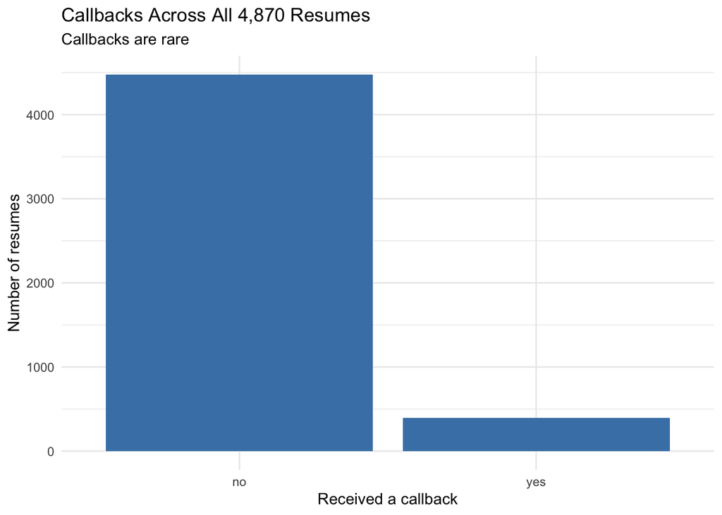

```r
resumes |>
  ggplot(aes(x = call)) +
  geom_bar(fill = "steelblue") +
  labs(
    title = "Callbacks Across All 4,870 Resumes",
    subtitle = "Callbacks are rare",
    x = "Received a callback",
    y = "Number of resumes"
  ) +
  theme_minimal()
```

Callbacks are rare: only about 8% of all resumes got one. Rare binary outcomes are exactly where a Bernoulli model (Justice) is needed and where intuitions based on averages of continuous outcomes can mislead.

Create a plot that shows the relationship between `call` and `ethnicity`.

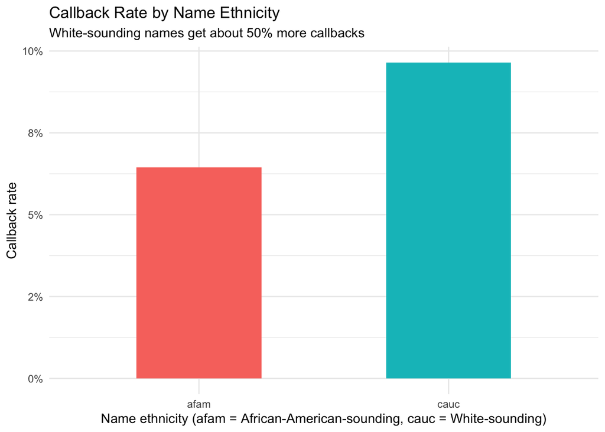

```r
resumes |>
  group_by(ethnicity) |>
  summarize(callback_rate = mean(call == "yes")) |>
  ggplot(aes(x = ethnicity, y = callback_rate, fill = ethnicity)) +
  geom_col(width = 0.5, show.legend = FALSE) +
  scale_y_continuous(labels = scales::percent_format(accuracy = 1)) +
  labs(
    title = "Callback Rate by Name Ethnicity",
    subtitle = "White-sounding names get about 50% more callbacks",
    x = "Name ethnicity (afam = African-American-sounding, cauc = White-sounding)",
    y = "Callback rate"
  ) +
  theme_minimal()
```

Resumes with white-sounding names were called back about 9.7% of the time, against 6.5% for black-sounding names — roughly 50% more callbacks, on a perfectly balanced design of 2,435 resumes per group.

## Justice

### Population Table

Describe the key components of a Population Table for your scenario.

**Historian:** One row per job application per moment in time, drawn from the population of entry-level job applications in large US cities around 1995–2005. The Data rows are the 4,870 fictitious resumes sent to Boston and Chicago employers in 2001; the Preceptor rows are real applications in Baltimore in 2000. The columns are Source, Applicant, Year, Callback, Race, and Sex.

**Civil rights organization:** One row per job application per moment in time, drawn from the population of applications submitted by people whose names signal a race in large US cities from roughly 2000 to today. The Data rows are the 2001 fictitious resumes; the Preceptor rows are Chicago applications today. The columns are Source, Applicant, Year, the two potential outcomes, and the Treatment.

Population Table --- Historian (predictive)<sup>1</sup>

| Source | Unit/Time<sup>2</sup> Applicant | Unit/Time<sup>2</sup> Year | Outcome<sup>3</sup> Callback | Covariates<sup>4</sup> Race | Covariates<sup>4</sup> Sex |
| --- | --- | --- | --- | --- | --- |
| … | … | … | … | … | … |
| Data | Emily Walsh | 2001 | Yes | White | Female |
| Data | Jamal Jones | 2001 | No | Black | Male |
| Data | … | … | … | … | … |
| Data | Lakisha Washington | 2001 | No | Black | Female |
| … | … | … | … | … | … |
| Preceptor | Lakisha Washington | 2000 | No | Black | Female |
| Preceptor | Greg Baker | 2000 | Yes | White | Male |
| Preceptor | … | … | … | … | … |
| Preceptor | Emily Walsh | 2000 | Yes | White | Female |
| … | … | … | … | … | … |

<sup>1</sup> This table combines the Bertrand and Mullainathan (2004) resume data with the historian's Baltimore applicants, both drawn from the population of entry-level job applications in large US cities around 1995-2005.  
<sup>2</sup> Data rows are 4,870 fictitious resumes sent in response to help-wanted ads in Boston and Chicago newspapers in 2001. Preceptor rows are real people applying for real jobs in Baltimore during 2000. The data's applicants never existed - a gap the representativeness discussion must address.  
<sup>3</sup> In Data rows, a callback is a phone or email response to the voicemail or address listed on the fictitious resume. In Preceptor rows, it is any employer contact inviting the applicant to the next stage.  
<sup>4</sup> In Data rows, Race is the race signaled by the randomly assigned name, not any person's actual race. In Preceptor rows, Race is the applicant's actual race. Treating these two columns as the same thing is the validity assumption.

Population Table --- Civil rights organization (causal)<sup>1</sup>

| Source | Unit/Time<sup>2</sup> Applicant | Unit/Time<sup>2</sup> Year | Potential Outcomes<sup>3</sup> Callback if Black Name | Potential Outcomes<sup>3</sup> Callback if White Name | Treatment<sup>4</sup> Name on Resume |
| --- | --- | --- | --- | --- | --- |
| … | … | … | … | … | … |
| Data | Emily Walsh | 2001 | … | Yes | White-sounding |
| Data | Jamal Jones | 2001 | No | … | Black-sounding |
| Data | … | … | … | … | … |
| Data | Lakisha Washington | 2001 | No | … | Black-sounding |
| … | … | … | … | … | … |
| Preceptor | Jamal Jones | 2026 | No | Yes | Black-sounding |
| Preceptor | Emily Walsh | 2026 | No | Yes | White-sounding |
| Preceptor | … | … | … | … | … |
| Preceptor | Lakisha Washington | 2026 | No | No | Black-sounding |
| … | … | … | … | … | … |

<sup>1</sup> This table combines the Bertrand and Mullainathan (2004) resume data with the civil rights organization's Chicago applications today, both drawn from the population of job applications carrying racially-coded names in large US cities from 2000 to today.  
<sup>2</sup> Data rows are fictitious resumes sent to Boston and Chicago employers in 2001. Preceptor rows are applications submitted in Chicago in 2026. The 25-year gap is the stability concern.  
<sup>3</sup> In Data rows, only the potential outcome matching the name the resume actually carried was observed; the other is shown as '...' because no one measured it. In Preceptor rows, both potential outcomes are filled in with the truth, and the unobservable one is cross-hatched.  
<sup>4</sup> In Data rows, the name was randomly assigned to the resume by the experimenters. In Preceptor rows, the name is whatever the applicant actually uses. Random assignment is what makes unconfoundedness credible in the data; nothing guarantees it in the Preceptor rows.

### Assumptions

Counter-example to the assumption of validity:

> The data’s “race” column records the race a *name* signals on a fictitious resume; the historian’s Preceptor Table records an applicant’s *actual* race. Those are different constructs: the connection between names and race was imperfect in 2001 and is weaker today. Likewise, a “callback” in the data is a phone message left on a voicemail box set up for a made-up person responding to a newspaper ad; a callback for today’s applicant is a response routed through an online portal, often after algorithmic resume screening. Same column names, different things.

Counter-example to the assumption of stability:

> The data were collected in 2001. If discrimination in hiring has decreased (or increased, or changed form — say, moving from name screening to algorithmic screening) since then, the relationship between the name on a resume and the callback outcome today is not the relationship in our data. The civil rights organization’s question is about *today*, 25 years after the data. Even the historian, asking about 2000, must assume nothing important changed between Baltimore’s labor market in 2000 and the 2001 field period.

Counter-example to the assumption of representativeness:

> The data are not a sample of any real applicant population: the resumes were invented, sent only in response to newspaper help-wanted ads, only for entry-level positions, and only in Boston and Chicago. Real applicants in Baltimore in 2000 — or Chicago today — differ in occupation mix, application channel, and resume content in ways the study’s design cannot reflect. Nothing about a made-up resume answering a 2001 newspaper ad guarantees it resembles the applications our two protagonists care about.

Counter-example to the assumption of unconfoundedness:

> **Historian:** none needed. Unconfoundedness applies only to causal questions; the historian’s model is predictive.

> **Civil rights organization:** the experimenters randomly assigned names to resumes, so treatment assignment should be independent of the potential outcomes and unconfoundedness should hold. The honest worry is execution, not design: if the assignment process was not carried out cleanly — for example, if better resumes were disproportionately given white-sounding names — the name would be confounded with resume quality.

### Probability Family and Link Function

What probability family should we use?

> Bernoulli Distribution

Why should we use that probability family?

> The outcome is binary — a resume either receives a callback or it does not — and the Bernoulli distribution is the distribution for a single yes/no outcome.

What is the link function for our outcome?

> The logit link. Our model will be a logistic regression.

## Courage

The abstract data generating mechanism coming out of Justice is:

$$\text{logit}\left(\Pr(Y = 1)\right) = \beta_0 + \beta_1 X_1 + \cdots + \beta_n X_n$$

### Candidate Models

Estimate a model in which `call` is the outcome and `city` is the only covariate.

```r
logistic_reg() |>
  fit(call ~ city, data = resumes)
```

```
parsnip model object


Call:  stats::glm(formula = call ~ city, family = stats::binomial, data = data)

Coefficients:
(Intercept)  citychicago
    -2.2315      -0.3973

Degrees of Freedom: 4869 Total (i.e. Null);  4868 Residual
Null Deviance:      2727
Residual Deviance: 2713     AIC: 2717
```

Printing the fitted model shows the estimated coefficients, but nothing about their uncertainty.

Display the coefficients and their confidence intervals.

```r
logistic_reg() |>
  fit(call ~ city, data = resumes) |>
  tidy(conf.int = TRUE)
```

```
# A tibble: 2 × 7
  term        estimate std.error statistic   p.value conf.low conf.high
  <chr>          <dbl>     <dbl>     <dbl>     <dbl>    <dbl>     <dbl>
1 (Intercept)   -2.23     0.0726    -30.7  2.22e-207   -2.38     -2.09
2 citychicago   -0.397    0.106      -3.76 1.70e-  4   -0.605    -0.190
```

The same pipe, extended with `tidy(conf.int = TRUE)`, turns the fit into a tidy table with 95% intervals. Location matters, but it says nothing yet about the question both scenarios actually care about — so we add the name’s ethnicity next.

Interpret the estimate for `citychicago`.

> Comparing resumes sent to Chicago with resumes sent to Boston, the Chicago resumes were less likely to get a callback: the coefficient is about −0.40 on the log-odds scale, with a 95% confidence interval (about −0.61 to −0.19) that excludes zero. Logistic coefficients are hard to read as raw numbers — the sign and the interval carry the message here, and outcome-scale answers wait for Temperance.

Estimate a model in which `call` is the outcome and `city` and `ethnicity` are the covariates.

```r
logistic_reg() |>
  fit(call ~ city + ethnicity, data = resumes)
```

```
parsnip model object


Call:  stats::glm(formula = call ~ city + ethnicity, family = stats::binomial,
    data = data)

Coefficients:
  (Intercept)    citychicago  ethnicitycauc
      -2.4707        -0.3987         0.4395

Degrees of Freedom: 4869 Total (i.e. Null);  4867 Residual
Null Deviance:      2727
Residual Deviance: 2696     AIC: 2702
```

Display the coefficients and their confidence intervals.

```r
logistic_reg() |>
  fit(call ~ city + ethnicity, data = resumes) |>
  tidy(conf.int = TRUE)
```

```
# A tibble: 3 × 7
  term          estimate std.error statistic   p.value conf.low conf.high
  <chr>            <dbl>     <dbl>     <dbl>     <dbl>    <dbl>     <dbl>
1 (Intercept)     -2.47     0.0964    -25.6  5.88e-145   -2.66     -2.29
2 citychicago     -0.399    0.106      -3.77 1.66e-  4   -0.607    -0.191
3 ethnicitycauc    0.439    0.107       4.09 4.33e-  5    0.230     0.652
```

The coefficient on `ethnicitycauc` excludes zero, and the city coefficient barely moves when ethnicity enters — which is what randomized name assignment should produce. The paper’s second headline finding is that resume quality pays off more for white-sounding names, so we test that next.

Interpret the estimate for `ethnicitycauc`.

> Comparing two resumes sent to the same city, the one with a white-sounding name was more likely to get a callback: about 0.44 on the log-odds scale, with a 95% confidence interval (about 0.23 to 0.65) that excludes zero, adjusting for city. Because names were randomly assigned to resumes, adding or removing other covariates barely moves this estimate.

Add `quality`, and its interaction with `ethnicity`, to the previous model.

```r
logistic_reg() |>
  fit(call ~ city + ethnicity + quality + ethnicity * quality, data = resumes)
```

```
parsnip model object


Call:  stats::glm(formula = call ~ city + ethnicity + quality + ethnicity *
    quality, family = stats::binomial, data = data)

Coefficients:
             (Intercept)               citychicago             ethnicitycauc
                -2.42710                  -0.39999                   0.52254
              qualitylow  ethnicitycauc:qualitylow
                -0.08788                  -0.17944

Degrees of Freedom: 4869 Total (i.e. Null);  4865 Residual
Null Deviance:      2727
Residual Deviance: 2692     AIC: 2702
```

Display the coefficients and their confidence intervals.

```r
logistic_reg() |>
  fit(call ~ city + ethnicity + quality + ethnicity * quality, data = resumes) |>
  tidy(conf.int = TRUE)
```

```
# A tibble: 5 × 7
  term                  estimate std.error statistic  p.value conf.low conf.high
  <chr>                    <dbl>     <dbl>     <dbl>    <dbl>    <dbl>     <dbl>
1 (Intercept)            -2.43       0.125   -19.4   4.00e-84   -2.68     -2.19
2 citychicago            -0.400      0.106    -3.78  1.59e- 4   -0.608    -0.193
3 ethnicitycauc           0.523      0.147     3.55  3.81e- 4    0.237     0.814
4 qualitylow             -0.0879     0.165    -0.531 5.95e- 1   -0.413     0.236
5 ethnicitycauc:qualit…  -0.179      0.216    -0.832 4.05e- 1   -0.603     0.244
```

Both the `quality` main effect and its interaction with `ethnicity` have confidence intervals that comfortably include zero. The paper’s pattern does not show up in this simple model, so we drop `quality` and instead keep covariates whose intervals exclude zero — plus `sex`, which the historian’s question forces us to include.

Interpret the estimate for the interaction `ethnicitycauc:qualitylow`.

> The interaction asks whether the white-name advantage differs between high-quality and low-quality resumes. The estimate is about −0.18 with a 95% confidence interval (about −0.60 to 0.24) that comfortably includes zero: in this simple model, we cannot distinguish the advantage on low-quality resumes from the advantage on high-quality ones.

### The Data Generating Mechanism

Which model should we choose, and why? Define `fit_resumes` as your chosen model and write out the fitted equation.

```r
fit_resumes <- logistic_reg() |>
  fit(call ~ sex + city + ethnicity + special, data = resumes)

fit_resumes |>
  tidy(conf.int = TRUE)
```

```
# A tibble: 5 × 7
  term          estimate std.error statistic   p.value conf.low conf.high
  <chr>            <dbl>     <dbl>     <dbl>     <dbl>    <dbl>     <dbl>
1 (Intercept)     -2.75      0.118   -23.3   1.56e-120   -2.98     -2.52
2 sexmale         -0.126     0.133    -0.950 3.42e-  1   -0.392     0.130
3 citychicago     -0.463     0.108    -4.28  1.85e-  5   -0.676    -0.252
4 ethnicitycauc    0.447     0.108     4.13  3.64e-  5    0.236     0.660
5 specialyes       0.817     0.108     7.57  3.72e- 14    0.606     1.03
```

We choose `call ~ sex + city + ethnicity + special`. The `city`, `ethnicity`, and `special` (special skills) coefficients all have confidence intervals excluding zero. The `sex` coefficient’s interval includes zero, but the historian’s question explicitly asks about differences by sex, so the question — not the data — forces it into the model. Quality stays out, per the previous model.

$$\text{logit}\left(\Pr(\text{call} = \text{yes})\right) = -2.75 - 0.13 \cdot \text{male} - 0.46 \cdot \text{chicago} + 0.45 \cdot \text{caucasian} + 0.82 \cdot \text{special}$$

Each indicator is 0/1. The intercept describes a female applicant in Boston with a black-sounding name and no special skills; each coefficient shifts the log-odds of a callback. **This is our data generating mechanism.**

### Model Checking

Use `check_predictions(extract_fit_engine(fit_resumes))` to perform a posterior predictive check of your chosen model.

```
Ignoring unknown labels:
• size : ""
• alpha : ""
```

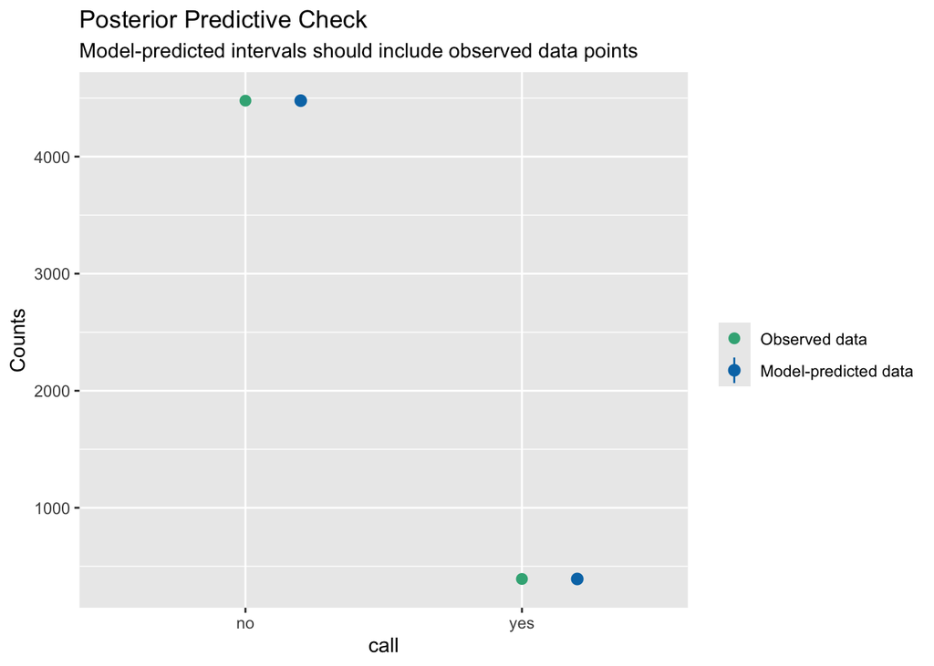

```r
check_predictions(extract_fit_engine(fit_resumes))
```

`check_predictions()` simulates new callback data from the fitted model and compares it to the data we observed. The simulated replicates bracket the observed share of callbacks, so the model is not obviously misdescribing the outcome — the check we want to pass before trusting the predictions in Temperance.

## Temperance

### Predictions

Use `predictions(fit_resumes, type = "prob")` to estimate the callback probability for individual resumes in the sample.

```r
predictions(fit_resumes, type = "prob") |>
  as_tibble() |>
  filter(group == "yes") |>
  select(ethnicity, city, sex, special, estimate, conf.low, conf.high) |>
  head(6)
```

```
# A tibble: 6 × 7
  ethnicity city    sex    special estimate conf.low conf.high
  <chr>     <chr>   <chr>  <chr>      <dbl>    <dbl>     <dbl>
1 cauc      chicago female no        0.0594   0.0476    0.0712
2 cauc      chicago female no        0.0594   0.0476    0.0712
3 afam      chicago female no        0.0388   0.0302    0.0475
4 afam      chicago female yes       0.0838   0.0668    0.101
5 cauc      chicago female no        0.0594   0.0476    0.0712
6 cauc      chicago male   yes       0.112    0.0809    0.143
```

`predictions()` returns one row per resume *per outcome class*; we filter to `group == "yes"` because the callback probability is what we care about. Each resume gets its own predicted probability, built from its own covariates — this is the stepping stone, not the answer.

Use `avg_predictions(fit_resumes, type = "prob", by = "ethnicity")` to estimate the average callback probability for resumes with black-sounding and white-sounding names.

```r
avg_predictions(fit_resumes, type = "prob", by = "ethnicity")
```

```
 Group ethnicity Estimate Std. Error     z Pr(>|z|)     S  2.5 % 97.5 %
   no       afam   0.9355    0.00494 189.3   <0.001   Inf 0.9258 0.9452
   no       cauc   0.9035    0.00593 152.5   <0.001   Inf 0.8919 0.9151
   yes      afam   0.0645    0.00494  13.0   <0.001 126.8 0.0548 0.0742
   yes      cauc   0.0965    0.00593  16.3   <0.001 195.7 0.0849 0.1081

Type: prob
```

Read the `yes` rows: these are the headline numbers — the average callback probability for each kind of name, with confidence intervals. (The `no` rows are their mirror images.)

What is the expected callback probability for an applicant with a black-sounding name (with 95% CI)?

> About 6.5%, with a 95% CI of roughly [5.5%, 7.4%].

What is the expected callback probability for an applicant with a white-sounding name (with 95% CI)?

> About 9.7%, with a 95% CI of roughly [8.5%, 10.8%].

### Comparisons

Use `avg_comparisons(fit_resumes, variables = "ethnicity", type = "prob")` to estimate the difference in callback probability between white-sounding and black-sounding names.

```r
avg_comparisons(fit_resumes, variables = "ethnicity", type = "prob")
```

```
 Group Estimate Std. Error     z Pr(>|z|)    S   2.5 %  97.5 %
   no   -0.0321    0.00772 -4.16   <0.001 15.0 -0.0473 -0.0170
   yes   0.0321    0.00772  4.16   <0.001 15.0  0.0170  0.0473

Term: ethnicity
Type: prob
Comparison: cauc - afam
```

The `yes` row is the single number the questions ask for: a white-sounding name is associated with a callback probability about 3.2 percentage points higher (95% CI roughly [1.7, 4.7]) than a black-sounding name. On a base rate of 6.5%, 3.2 points is enormous — about 50% more callbacks. In practical terms, an applicant with a black-sounding name must send roughly 15 resumes to expect one callback; an identical resume with a white-sounding name needs about 10.

### Visualizations

Create a visualization of the average predictions by ethnicity using `plot_predictions()`.

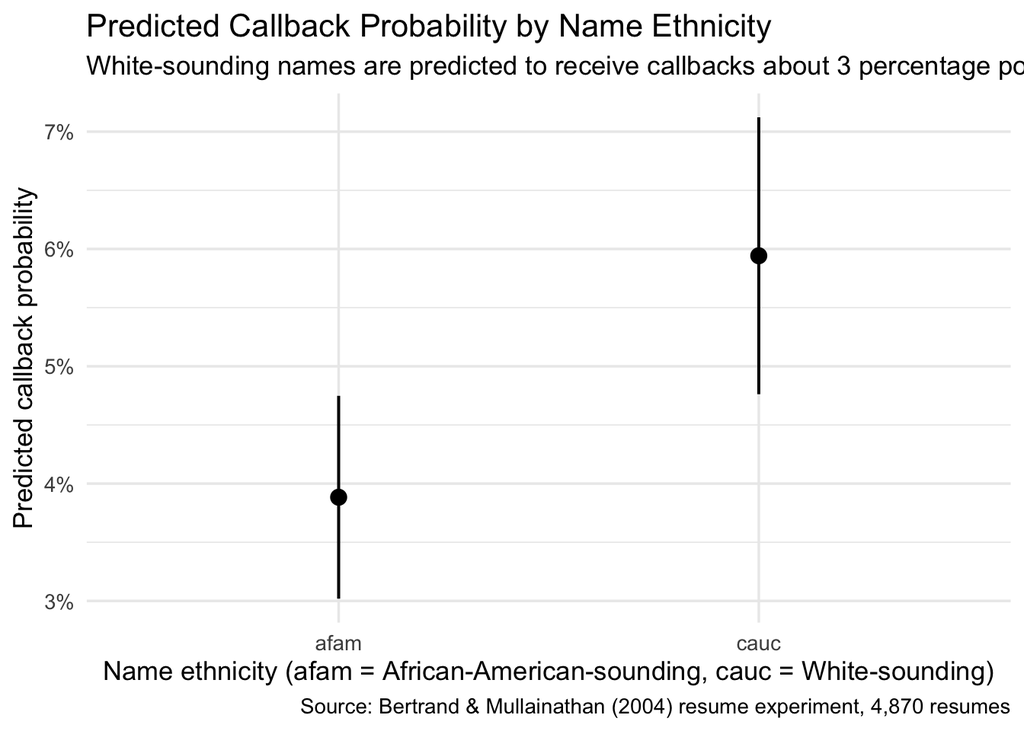

```r
plot_predictions(fit_resumes, condition = "ethnicity", type = "prob", draw = FALSE) |>
  filter(group == "yes") |>
  ggplot(aes(x = ethnicity, y = estimate)) +
  geom_pointrange(aes(ymin = conf.low, ymax = conf.high), linewidth = 0.7) +
  scale_y_continuous(labels = scales::percent_format(accuracy = 1)) +
  labs(
    title = "Predicted Callback Probability by Name Ethnicity",
    subtitle = "White-sounding names are predicted to receive callbacks about 3 percentage points more often",
    x = "Name ethnicity (afam = African-American-sounding, cauc = White-sounding)",
    y = "Predicted callback probability",
    caption = "Source: Bertrand & Mullainathan (2004) resume experiment, 4,870 resumes"
  ) +
  theme_minimal(base_size = 13)
```

### Interpretation

How does the historian interpret the difference in callback probabilities? How does the civil rights organization interpret the same number differently?

> **Historian:** the 3.2-point gap is a *comparison across rows* — applicants with black-sounding names got callbacks less often than applicants with white-sounding names. It describes the process that sorted applicants into jobs; it makes no claim about what would have happened to any particular applicant under a different name.

> **Civil rights organization:** the same 3.2 points is an estimate of a *within-row* quantity — the average difference between each application’s two potential outcomes. Because names were randomly assigned, the across-group comparison identifies the average causal effect: putting a black-sounding name on an otherwise identical resume *causes* roughly a one-third drop in the chance of a callback.

### Humility

Besides the average callback probabilities, identify two additional quantities of interest the person in your scenario might care about.

> **Historian:** the callback gap by *sex* (her question names it directly, and our model’s `sex` coefficient addresses it), and how the racial gap differed between cities — was Baltimore likely closer to the Boston pattern or the Chicago pattern?

Why might these estimates be a poor answer to your scenario’s question? Identify at least two possible sources of bias.

> 1. The data are 25 years old (or, for the historian, from different cities than Baltimore). If hiring discrimination has changed in level or form since 2001 — or differed between Baltimore and Boston/Chicago in 2000 — the stability and representativeness gaps discussed in Justice bias our answer in ways the confidence intervals do not capture.
> 2. The resumes were fictitious, sent only to newspaper help-wanted ads for entry-level jobs. Real applicant pools, real resumes, and modern online application channels may respond differently, so the estimated gap may not transfer to either protagonist’s actual population of applications.
> 3. The world is always more uncertain than our models would have us believe: even with every assumption exactly right, the reported intervals are only the *Preceptor’s Posterior* — the best posterior achievable under our assumptions — not the truth.